# SARIMA

Kelompok 9

2023-11-06

## library

```r
library("forecast")
```

```r
library("graphics")
library("TTR")
library("TSA")
library("rio")
library("ggplot2")
library("kableExtra")
library("astsa")
library("car")
library("portes")
library("MASS")
library("tseries")
library("rugarch")
library("lmtest")
library("FinTS")
```

## Input data

```r
data <- read.csv("https://raw.githubusercontent.com/Raziqizzan03/MPDW/main/data/(Full%20Data)%20Data%20Pendatang%20Mancanegara%20di%20Provinsi%20Bali%20(1).csv")
data<-data[,2:3]
```

# Eksplorasi data

### plot Data full

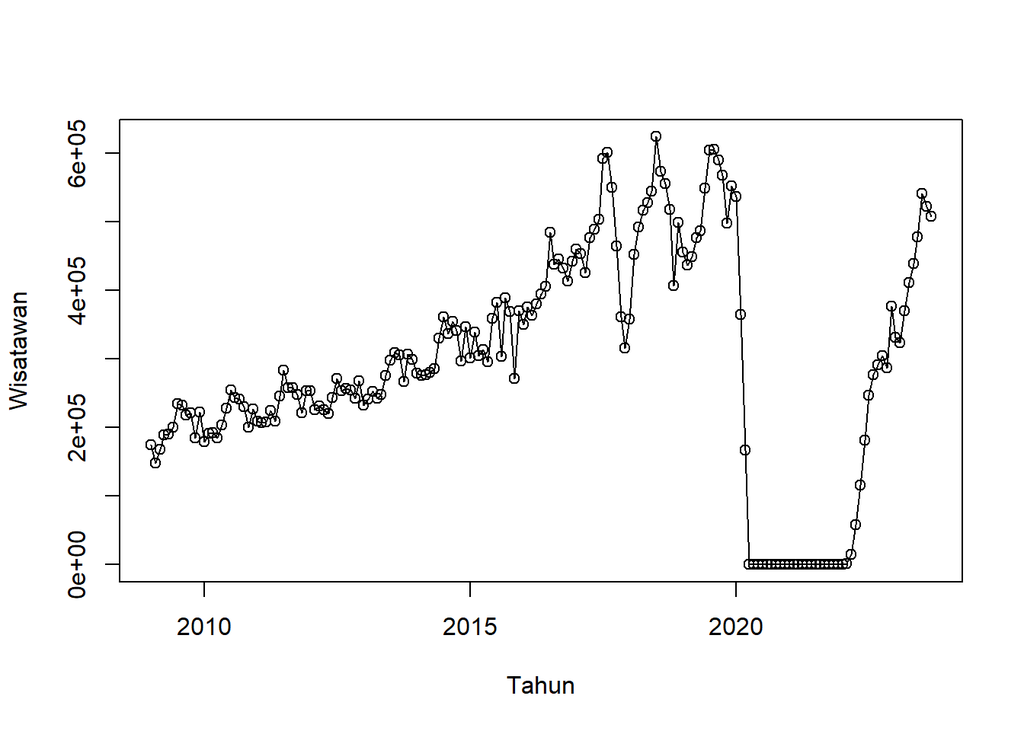

```r
plot_wisatawan = ts(data$Jumlah, frequency = 12, start= 2009)
plot(plot_wisatawan,
     xlab = "Tahun", ylab="Wisatawan")
points(plot_wisatawan)
```

### Pembagian data uji data latih

```r
data_training<-data[1:166,2]
training_ts<-ts(data_training,start=c(2009,1),frequency=12)
data_testing<-data[167:177,2]
testing_ts<-ts(data_testing, start = c(2022,11), frequency = 12)
```

data training = januari 2009-oktober 2022 data uji = november 2022- september 2023

### PLot data uji dan data latih

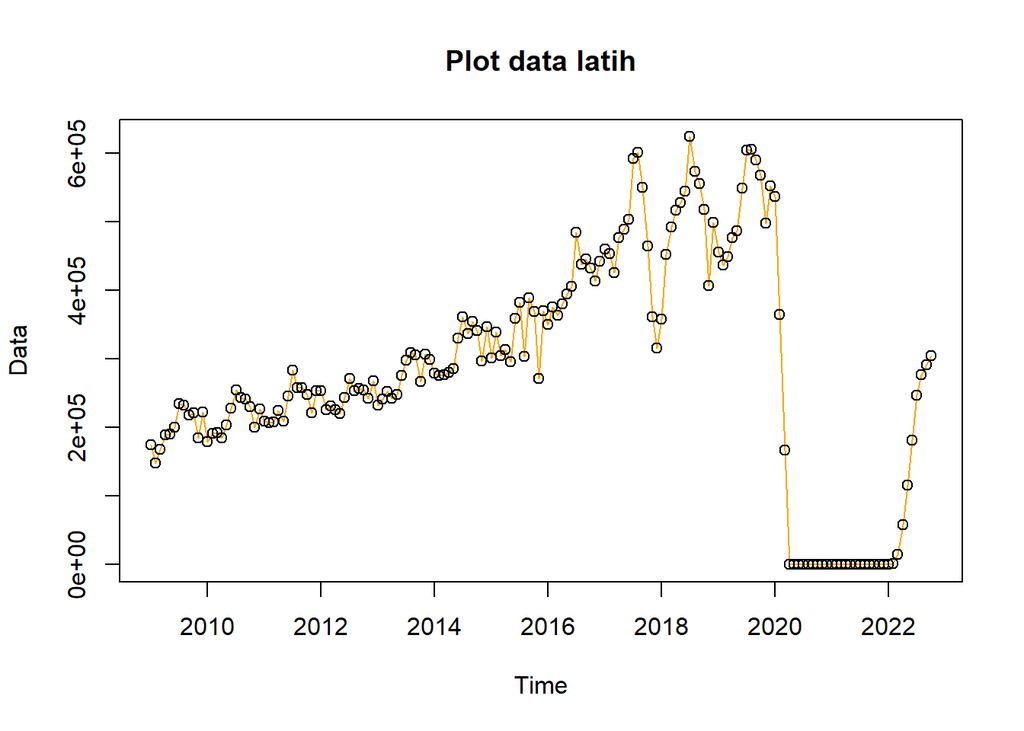

```r
# data latih
ts.plot(training_ts, col="orange",main="Plot data latih", type="o",xlab="Time",ylab="Data")
points(training_ts)
```

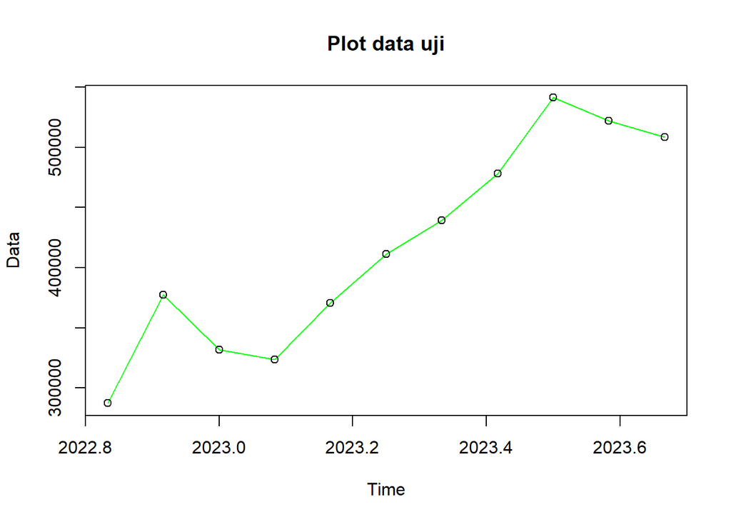

```r
# data uji
ts.plot(testing_ts, col="green",main="Plot data uji", type="o",xlab="Time",ylab="Data")
points(testing_ts)
```

# Uji kestasioneran data

### plot acf

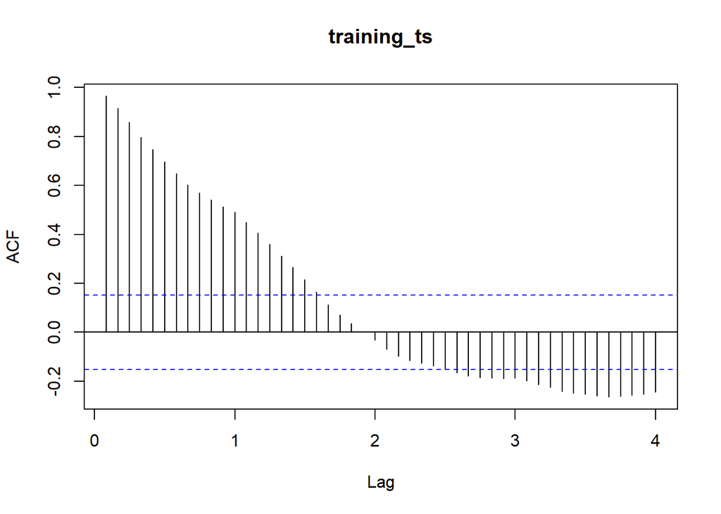

```r
Acf(training_ts, lag.max = 48)
```

Berdasarkan plot ACF, terlihat bahwa plot ACF pada data tersebut cenderung *tails off slowly*. menandakan bahwa data tersebut tidak stasioner dalam rataan

### Uji ADF

```r
tseries::adf.test(training_ts)
```

```
##
##  Augmented Dickey-Fuller Test
##
## data:  training_ts
## Dickey-Fuller = -2.1932, Lag order = 5, p-value = 0.4957
## alternative hypothesis: stationary
```

$H_0$ : Data tidak stasioner dalam rataan

$H_1$ : Data stasioner dalam rataan

Berdasarkan uji ADF tersebut, didapat *p-value* sebesar 0.4957 yang lebih besar dari taraf nyata 5% sehingga tak tolak $H_0$ dan menandakan bahwa data tidak stasioner dalam rataan. Hal ini sesuai dengan hasil eksplorasi menggunakan plot time series dan plot ACF.

### Plot Box-Cox

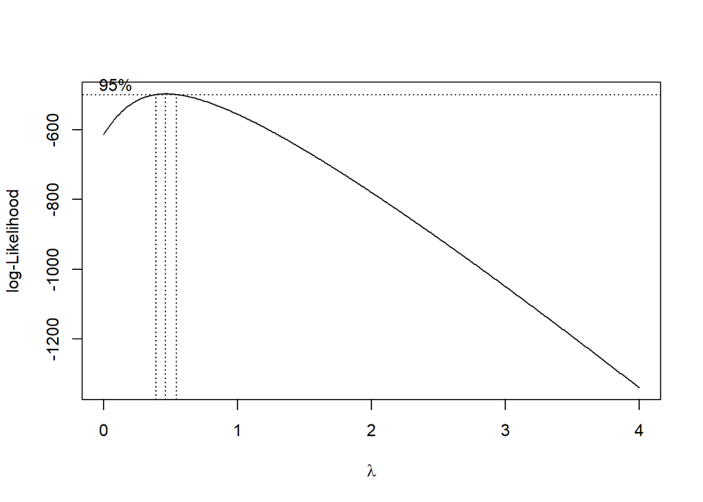

```r
index <- seq(1:166)
bc = boxcox(training_ts~index, lambda = seq(0,4,by=0.01))
```

```r
#Nilai Rounded Lambda
lambda <- bc$x[which.max(bc$y)]
lambda
```

```
## [1] 0.46
```

```r
#SK
bc$x[bc$y > max(bc$y) - 1/2 * qchisq(.95,1)]
```

```
##  [1] 0.40 0.41 0.42 0.43 0.44 0.45 0.46 0.47 0.48 0.49 0.50 0.51 0.52 0.53 0.54
```

# Penanganan kestasioneran

### Transformasi logaritma

```r
training_ts <- log(training_ts)
testing_ts <- log(testing_ts)
```

### Diferencing non musiman

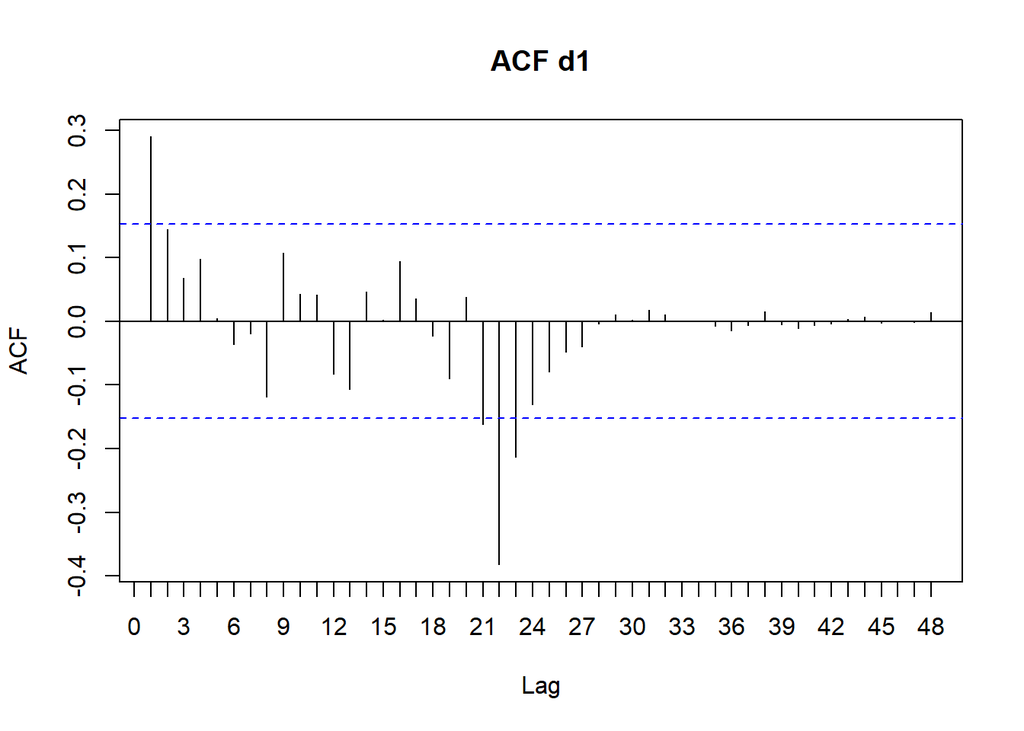

```r
training_diffnonmusiman <- diff(training_ts, differences = 1)
acf1 <- acf(training_diffnonmusiman,lag.max=48,xaxt="n", main="ACF d1")
     axis(1, at=0:48/12, labels=0:48)
```

### Diferencing non musiman dan musiman

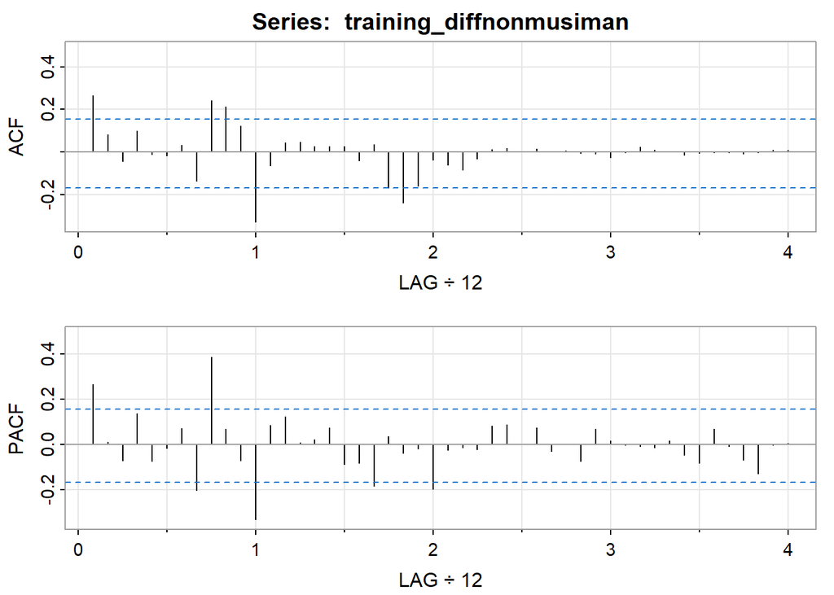

```
##      [,1] [,2]  [,3] [,4]  [,5]  [,6] [,7]  [,8] [,9] [,10] [,11] [,12] [,13]
## ACF  0.27 0.08 -0.04 0.10 -0.01 -0.02 0.03 -0.14 0.24  0.21  0.12 -0.33 -0.07
## PACF 0.27 0.01 -0.07 0.14 -0.07 -0.02 0.07 -0.20 0.39  0.07 -0.07 -0.33  0.08
##      [,14] [,15] [,16] [,17] [,18] [,19] [,20] [,21] [,22] [,23] [,24] [,25]
## ACF   0.05  0.05  0.03  0.03  0.03 -0.04  0.03 -0.17 -0.24 -0.16 -0.04 -0.06
## PACF  0.12  0.01  0.02  0.07 -0.09 -0.08 -0.18  0.04 -0.04 -0.02 -0.20 -0.03
##      [,26] [,27] [,28] [,29] [,30] [,31] [,32] [,33] [,34] [,35] [,36] [,37]
## ACF  -0.08 -0.03  0.01  0.02     0  0.01  0.00     0  0.00 -0.01 -0.02     0
## PACF -0.01 -0.02  0.08  0.09     0  0.07 -0.03     0 -0.07  0.07  0.02     0
##      [,38] [,39] [,40] [,41] [,42] [,43] [,44] [,45] [,46] [,47] [,48]
## ACF   0.02  0.01  0.00 -0.02 -0.01  0.00  0.00 -0.01  0.00  0.01  0.01
## PACF -0.01 -0.01  0.02 -0.05 -0.08  0.07 -0.01 -0.07 -0.13  0.00  0.01
```

```r
diff12.turis <- diff(training_ts,lag=12)
training_diffnonmusiman <- diff(diff12.turis,differencing=1)
acf2(training_diffnonmusiman)
```

# Identifikasi model

### pemilihan model

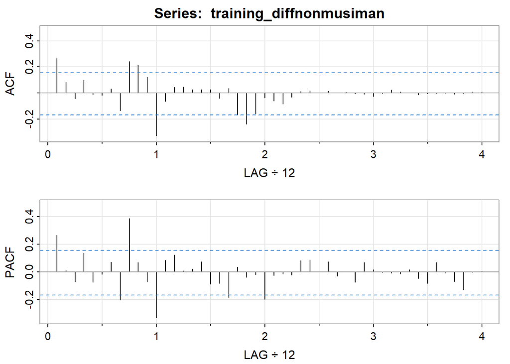

```
##      [,1] [,2]  [,3] [,4]  [,5]  [,6] [,7]  [,8] [,9] [,10] [,11] [,12] [,13]
## ACF  0.27 0.08 -0.04 0.10 -0.01 -0.02 0.03 -0.14 0.24  0.21  0.12 -0.33 -0.07
## PACF 0.27 0.01 -0.07 0.14 -0.07 -0.02 0.07 -0.20 0.39  0.07 -0.07 -0.33  0.08
##      [,14] [,15] [,16] [,17] [,18] [,19] [,20] [,21] [,22] [,23] [,24] [,25]
## ACF   0.05  0.05  0.03  0.03  0.03 -0.04  0.03 -0.17 -0.24 -0.16 -0.04 -0.06
## PACF  0.12  0.01  0.02  0.07 -0.09 -0.08 -0.18  0.04 -0.04 -0.02 -0.20 -0.03
##      [,26] [,27] [,28] [,29] [,30] [,31] [,32] [,33] [,34] [,35] [,36] [,37]
## ACF  -0.08 -0.03  0.01  0.02     0  0.01  0.00     0  0.00 -0.01 -0.02     0
## PACF -0.01 -0.02  0.08  0.09     0  0.07 -0.03     0 -0.07  0.07  0.02     0
##      [,38] [,39] [,40] [,41] [,42] [,43] [,44] [,45] [,46] [,47] [,48]
## ACF   0.02  0.01  0.00 -0.02 -0.01  0.00  0.00 -0.01  0.00  0.01  0.01
## PACF -0.01 -0.01  0.02 -0.05 -0.08  0.07 -0.01 -0.07 -0.13  0.00  0.01
```

```r
acf2(training_diffnonmusiman)
```

model tentatif yg terbentuk $Arima(0,1,1)(0,1,1)_{12}$, $Arima(1,1,0)(2,1,0)_{12}$, $Arima(0,1,1)(2,1,0)_{12}$, $Arima(1,1,0)(0,1,1)_{12}$, $Arima(1,1,1)(0,1,1)_{12}$ $Arima(1,1,1)(2,1,0)_{12}$, $Arima(0,1,1)(2,1,1)_{12}$, $Arima(1,1,0)(2,1,1)_{12}$

# Seleksi Model

### Arima(0,1,1)(0,1,1)_{12}

```r
fit1<-Arima(training_ts, order = c(0,1,1), seasonal=list(order=c(0,1,1), periode=12), method = "ML")
coeftest(fit1)
```

```
##
## z test of coefficients:
##
##       Estimate Std. Error z value  Pr(>|z|)
## ma1   0.263360   0.068481  3.8457 0.0001202 ***
## sma1 -0.933747   0.163876 -5.6979 1.213e-08 ***
## ---
## Signif. codes:  0 '***' 0.001 '**' 0.01 '*' 0.05 '.' 0.1 ' ' 1
```

```r
summary(fit1) #oke
```

```
## Series: training_ts
## ARIMA(0,1,1)(0,1,1)[12]
##
## Coefficients:
##          ma1     sma1
##       0.2634  -0.9337
## s.e.  0.0685   0.1639
##
## sigma^2 = 0.6916:  log likelihood = -199.25
## AIC=404.5   AICc=404.66   BIC=413.59
##
## Training set error measures:
##                       ME     RMSE       MAE       MPE     MAPE      MASE
## Training set 0.006561171 0.793135 0.2734532 -2.326352 9.520997 0.1695814
##                   ACF1
## Training set 0.0413883
```

### Arima(1,1,0)(2,1,0)_{12}

```r
fit2<-Arima(training_ts, order = c(1,1,0), seasonal=list(order=c(2,1,0), periode=12), method = "ML")
coeftest(fit2)
```

```
##
## z test of coefficients:
##
##       Estimate Std. Error z value  Pr(>|z|)
## ar1   0.340975   0.078304  4.3545 1.334e-05 ***
## sar1 -0.798394   0.089880 -8.8829 < 2.2e-16 ***
## sar2 -0.546885   0.108070 -5.0605 4.182e-07 ***
## ---
## Signif. codes:  0 '***' 0.001 '**' 0.01 '*' 0.05 '.' 0.1 ' ' 1
```

```r
summary(fit2) #oke
```

```
## Series: training_ts
## ARIMA(1,1,0)(2,1,0)[12]
##
## Coefficients:
##          ar1     sar1     sar2
##       0.3410  -0.7984  -0.5469
## s.e.  0.0783   0.0899   0.1081
##
## sigma^2 = 0.7686:  log likelihood = -201.63
## AIC=411.26   AICc=411.53   BIC=423.38
##
## Training set error measures:
##                      ME      RMSE       MAE       MPE     MAPE      MASE
## Training set 0.01537422 0.8333543 0.2973771 -1.927487 10.94776 0.1844177
##                     ACF1
## Training set -0.03086245
```

### Arima(0,1,1)(2,1,0)_{12}

```r
fit3<-Arima(training_ts, order = c(0,1,1), seasonal=list(order=c(2,1,0), periode=12), method = "ML") #signifikan
coeftest(fit3)
```

```
##
## z test of coefficients:
##
##       Estimate Std. Error z value  Pr(>|z|)
## ma1   0.267360   0.067807  3.9430 8.048e-05 ***
## sar1 -0.776323   0.089374 -8.6862 < 2.2e-16 ***
## sar2 -0.580506   0.101737 -5.7059 1.157e-08 ***
## ---
## Signif. codes:  0 '***' 0.001 '**' 0.01 '*' 0.05 '.' 0.1 ' ' 1
```

```r
summary(fit3) #oke
```

```
## Series: training_ts
## ARIMA(0,1,1)(2,1,0)[12]
##
## Coefficients:
##          ma1     sar1     sar2
##       0.2674  -0.7763  -0.5805
## s.e.  0.0678   0.0894   0.1017
##
## sigma^2 = 0.7841:  log likelihood = -203.6
## AIC=415.2   AICc=415.47   BIC=427.32
##
## Training set error measures:
##                      ME     RMSE       MAE       MPE     MAPE      MASE
## Training set 0.01779137 0.841734 0.3026163 -2.043113 10.85907 0.1876668
##                    ACF1
## Training set 0.04705189
```

### Arima(1,1,0)(0,1,1)_{12}

```r
fit4<-Arima(training_ts, order = c(1,1,0), seasonal=list(order=c(0,1,1), periode=12), method = "ML") #signifikan
coeftest(fit4)
```

```
##
## z test of coefficients:
##
##       Estimate Std. Error z value  Pr(>|z|)
## ar1   0.319318   0.076939  4.1503 3.321e-05 ***
## sma1 -0.900845   0.116687 -7.7202 1.162e-14 ***
## ---
## Signif. codes:  0 '***' 0.001 '**' 0.01 '*' 0.05 '.' 0.1 ' ' 1
```

```r
summary(fit4) #oke
```

```
## Series: training_ts
## ARIMA(1,1,0)(0,1,1)[12]
##
## Coefficients:
##          ar1     sma1
##       0.3193  -0.9008
## s.e.  0.0769   0.1167
##
## sigma^2 = 0.6928:  log likelihood = -197.73
## AIC=401.46   AICc=401.62   BIC=410.55
##
## Training set error measures:
##                       ME      RMSE       MAE       MPE     MAPE      MASE
## Training set 0.007183961 0.7938668 0.2722242 -2.106695 9.875723 0.1688192
##                     ACF1
## Training set -0.02094897
```

### Arima(1,1,1)(0,1,1)_{12}

```r
fit5<-Arima(training_ts, order = c(1,1,1), seasonal=list(order=c(0,1,1), periode=12), method = "ML") #signifikan
coeftest(fit5)
```

```
##
## z test of coefficients:
##
##      Estimate Std. Error z value Pr(>|z|)
## ar1   0.51815    0.21006  2.4667  0.01364 *
## ma1  -0.22246    0.24019 -0.9262  0.35436
## sma1 -0.89204    0.10865 -8.2105  < 2e-16 ***
## ---
## Signif. codes:  0 '***' 0.001 '**' 0.01 '*' 0.05 '.' 0.1 ' ' 1
```

```r
summary(fit5)
```

```
## Series: training_ts
## ARIMA(1,1,1)(0,1,1)[12]
##
## Coefficients:
##          ar1      ma1     sma1
##       0.5181  -0.2225  -0.8920
## s.e.  0.2101   0.2402   0.1086
##
## sigma^2 = 0.6975:  log likelihood = -197.34
## AIC=402.68   AICc=402.95   BIC=414.8
##
## Training set error measures:
##                       ME      RMSE      MAE       MPE   MAPE     MASE
## Training set 0.006947331 0.7938713 0.265864 -1.986774 9.7375 0.164875
##                    ACF1
## Training set 0.00181909
```

### Arima(1,1,1)(2,1,0)_{12}

```r
fit6<-Arima(training_ts, order = c(1,1,1), seasonal=list(order=c(2,1,0), periode=12), method = "ML") #signifikan
coeftest(fit6)
```

```
##
## z test of coefficients:
##
##       Estimate Std. Error z value  Pr(>|z|)
## ar1   0.577943   0.171468  3.3706 0.0007502 ***
## ma1  -0.263543   0.197739 -1.3328 0.1826044
## sar1 -0.817356   0.090954 -8.9865 < 2.2e-16 ***
## sar2 -0.533355   0.109858 -4.8550 1.204e-06 ***
## ---
## Signif. codes:  0 '***' 0.001 '**' 0.01 '*' 0.05 '.' 0.1 ' ' 1
```

```r
summary(fit6)
```

```
## Series: training_ts
## ARIMA(1,1,1)(2,1,0)[12]
##
## Coefficients:
##          ar1      ma1     sar1     sar2
##       0.5779  -0.2635  -0.8174  -0.5334
## s.e.  0.1715   0.1977   0.0910   0.1099
##
## sigma^2 = 0.7673:  log likelihood = -200.9
## AIC=411.8   AICc=412.21   BIC=426.96
##
## Training set error measures:
##                      ME      RMSE       MAE       MPE     MAPE      MASE
## Training set 0.01324124 0.8298908 0.2894819 -1.836935 10.56219 0.1795215
##                      ACF1
## Training set -0.002128735
```

### Arima(0,1,1)(2,1,1)_{12}

```r
fit7<-Arima(training_ts, order = c(0,1,1), seasonal=list(order=c(2,1,1), periode=12), method = "ML") #signifikan
coeftest(fit7)
```

```
##
## z test of coefficients:
##
##       Estimate Std. Error z value  Pr(>|z|)
## ma1   0.251951   0.070412  3.5783 0.0003459 ***
## sar1 -0.282026   0.147026 -1.9182 0.0550852 .
## sar2 -0.310027   0.143601 -2.1589 0.0308548 *
## sma1 -0.716231   0.130899 -5.4716 4.459e-08 ***
## ---
## Signif. codes:  0 '***' 0.001 '**' 0.01 '*' 0.05 '.' 0.1 ' ' 1
```

```r
summary(fit7)
```

```
## Series: training_ts
## ARIMA(0,1,1)(2,1,1)[12]
##
## Coefficients:
##          ma1    sar1     sar2     sma1
##       0.2520  -0.282  -0.3100  -0.7162
## s.e.  0.0704   0.147   0.1436   0.1309
##
## sigma^2 = 0.6946:  log likelihood = -196.74
## AIC=403.48   AICc=403.89   BIC=418.63
##
## Training set error measures:
##                        ME      RMSE       MAE       MPE     MAPE     MASE
## Training set -0.004536118 0.7896122 0.2638371 -2.638055 8.917547 0.163618
##                   ACF1
## Training set 0.0315931
```

### Arima(1,1,0)(2,1,1)_{12}

```r
fit8<-Arima(training_ts, order = c(1,1,0), seasonal=list(order=c(2,1,1), periode=12), method = "ML") #signifikan
coeftest(fit8)
```

```
##
## z test of coefficients:
##
##       Estimate Std. Error z value Pr(>|z|)
## ar1   0.300968   0.079889  3.7673 0.000165 ***
## sar1 -0.295519   0.152943 -1.9322 0.053332 .
## sar2 -0.267342   0.152866 -1.7489 0.080314 .
## sma1 -0.702914   0.136830 -5.1371 2.79e-07 ***
## ---
## Signif. codes:  0 '***' 0.001 '**' 0.01 '*' 0.05 '.' 0.1 ' ' 1
```

```r
summary(fit8)
```

```
## Series: training_ts
## ARIMA(1,1,0)(2,1,1)[12]
##
## Coefficients:
##          ar1     sar1     sar2     sma1
##       0.3010  -0.2955  -0.2673  -0.7029
## s.e.  0.0799   0.1529   0.1529   0.1368
##
## sigma^2 = 0.691:  log likelihood = -195.66
## AIC=401.32   AICc=401.73   BIC=416.48
##
## Training set error measures:
##                        ME      RMSE       MAE       MPE     MAPE      MASE
## Training set -0.001781354 0.7875345 0.2611492 -2.378229 9.071976 0.1619511
##                     ACF1
## Training set -0.01659048
```

### Perbandingan model yg signifikan

```r
aic_model_ov <- data.frame( "Nama Model" =c("ARIMA(0,1,1)×ARIMA(0,1,1)_{12}","ARIMA(1,1,0)×ARIMA(2,1,0)_{12}","ARIMA(0,1,1)×ARIMA(2,1,0)_{12}","ARIMA(1,1,0)×ARIMA(0,1,1)_{12}"),"AIC" = c(fit1$aic,fit2$aic,fit3$aic,fit4$aic))
aic_model_ov
```

```
##                       Nama.Model      AIC
## 1 ARIMA(0,1,1)×ARIMA(0,1,1)_{12} 404.4995
## 2 ARIMA(1,1,0)×ARIMA(2,1,0)_{12} 411.2566
## 3 ARIMA(0,1,1)×ARIMA(2,1,0)_{12} 415.1990
## 4 ARIMA(1,1,0)×ARIMA(0,1,1)_{12} 401.4628
```

```r
dplyr::arrange(.data=aic_model_ov, AIC)
```

```
##                       Nama.Model      AIC
## 1 ARIMA(1,1,0)×ARIMA(0,1,1)_{12} 401.4628
## 2 ARIMA(0,1,1)×ARIMA(0,1,1)_{12} 404.4995
## 3 ARIMA(1,1,0)×ARIMA(2,1,0)_{12} 411.2566
## 4 ARIMA(0,1,1)×ARIMA(2,1,0)_{12} 415.1990
```

dapat dilihat bahwa model dengan aic terkecil dan parameter signifikan adalah Arima(1,1,0)(0,1,1)

# Overfitting

### Arima(2,1,0)(0,1,1)_{12}

```r
#===== OVERFITTING
overfit<-Arima(training_ts, order = c(2,1,0), seasonal=list(order=c(0,1,1), periode=12), method = "ML")
coeftest(overfit)
```

```
##
## z test of coefficients:
##
##       Estimate Std. Error z value  Pr(>|z|)
## ar1   0.297450   0.080637  3.6887 0.0002254 ***
## ar2   0.070132   0.080719  0.8688 0.3849359
## sma1 -0.890096   0.107821 -8.2553 < 2.2e-16 ***
## ---
## Signif. codes:  0 '***' 0.001 '**' 0.01 '*' 0.05 '.' 0.1 ' ' 1
```

```r
summary(overfit)
```

```
## Series: training_ts
## ARIMA(2,1,0)(0,1,1)[12]
##
## Coefficients:
##          ar1     ar2     sma1
##       0.2974  0.0701  -0.8901
## s.e.  0.0806  0.0807   0.1078
##
## sigma^2 = 0.6984:  log likelihood = -197.36
## AIC=402.71   AICc=402.98   BIC=414.83
##
## Training set error measures:
##                       ME      RMSE       MAE       MPE     MAPE     MASE
## Training set 0.007174202 0.7943943 0.2670558 -2.013276 9.776395 0.165614
##                     ACF1
## Training set 0.000965328
```

Tetap model yg terpilih adalah Arima(1,1,0)(0,1,1)

# diagnostik sisaan

### Eksplorasi data

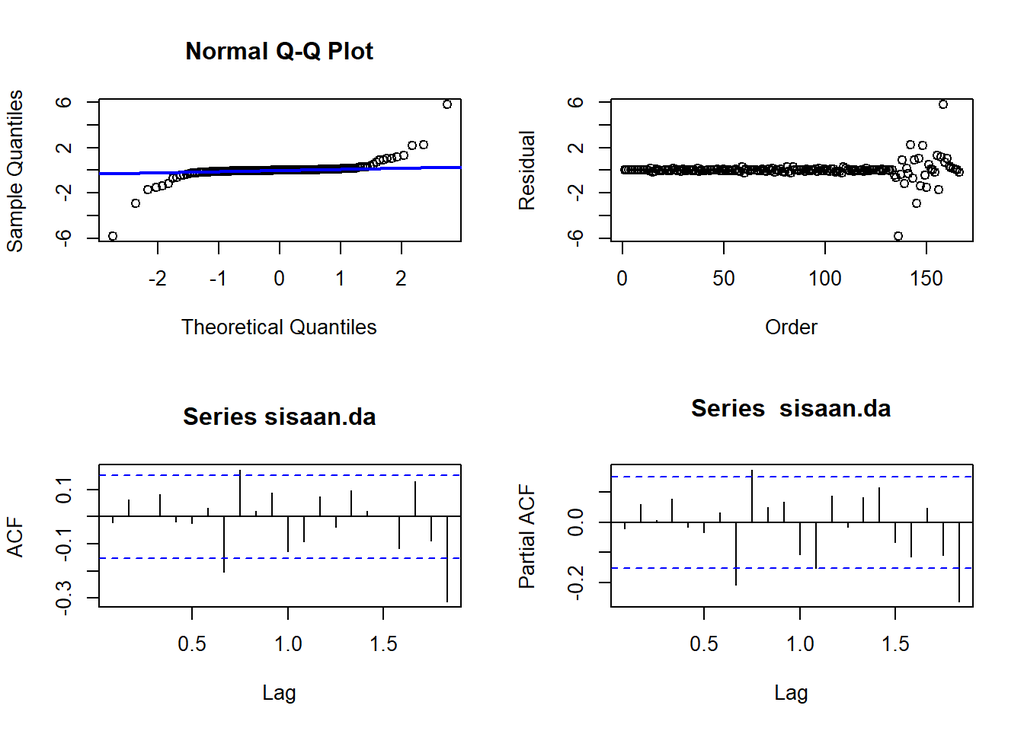

```r
sisaan.da <- fit4$residuals
par(mfrow=c(2,2))
qqnorm(sisaan.da)
qqline(sisaan.da, col = "blue", lwd = 2)
plot(c(1:length(sisaan.da)),sisaan.da, xlab = "Order", ylab = "Residual")
acf(sisaan.da)
pacf(sisaan.da)
```

```r
par(mfrow = c(1,1))
```

# Uji formal

### 1) Sisaan Menyebar Normal

```r
ks.test(fit4$residuals,"pnorm")
```

```
##
##  Asymptotic one-sample Kolmogorov-Smirnov test
##
## data:  fit4$residuals
## D = 0.33743, p-value < 2.2e-16
## alternative hypothesis: two-sided
```

$H_0$ : Sisaan menyebar normal

$H_1$ : Sisaan tidak menyebar normal

Berdasarkan uji KS tersebut, didapat *p-value* sebesar 2.2e-16 yang kurang dari taraf nyata 5% sehingga tolak $H_0$ dan menandakan bahwa sisaan tidak menyebar normal. Hal ini sesuai dengan hasil eksplorasi menggunakan plot kuantil-kuantil normal.

### 2) Sisaan saling bebas/tidak ada autokorelasi

```r
Box.test(fit4$residuals, lag = 20, type = "Ljung-Box")
```

```
##
##  Box-Ljung test
##
## data:  fit4$residuals
## X-squared = 29.543, df = 20, p-value = 0.0776
```

$H_0$ : Sisaan saling bebas

$H_1$ : Sisaan tidak tidak saling bebas

Berdasarkan uji Ljung-Box tersebut, didapat *p-value* sebesar 0.0776 yang lebih besar dari taraf nyata 5% sehingga tak tolak $H_0$ dan menandakan bahwa sisaan saling bebas.

### 3) Sisaan homogen

```r
#ragam homogen
Box.test((fit4$residuals)^2, type = "Ljung")
```

```
##
##  Box-Ljung test
##
## data:  (fit4$residuals)^2
## X-squared = 0.11163, df = 1, p-value = 0.7383
```

$H_0$ : Ragam sisaan homogen

$H_1$ : Ragam sisaan tidak homogen

Berdasarkan uji Ljung-Box terhadap sisaan kuadrat tersebut, didapat *p-value* sebesar $0.7383$ yang lebih besar dari taraf nyata 5% sehingga tak tolak $H_0$ dan menandakan bahwa ragam sisaan homogen.

### 4) Nilai tengah sisaan sama dengan nol

```r
t.test(fit4$residuals, mu = 0, conf.level = 0.95)
```

```
##
##  One Sample t-test
##
## data:  fit4$residuals
## t = 0.11625, df = 165, p-value = 0.9076
## alternative hypothesis: true mean is not equal to 0
## 95 percent confidence interval:
##  -0.1148366  0.1292045
## sample estimates:
##   mean of x
## 0.007183961
```

$H_0$ : nilai tengah sisaan sama dengan 0

$H_1$ : nilai tengah sisaan tidak sama dengan 0

Berdasarkan uji-ttersebut, didapat *p-value* sebesar 0.9076 yang lebih besar dari taraf nyata 5% sehingga tak tolak $H_0$ dan menandakan bahwa nilai tengah sisaan sama dengan nol.

# Peramalan

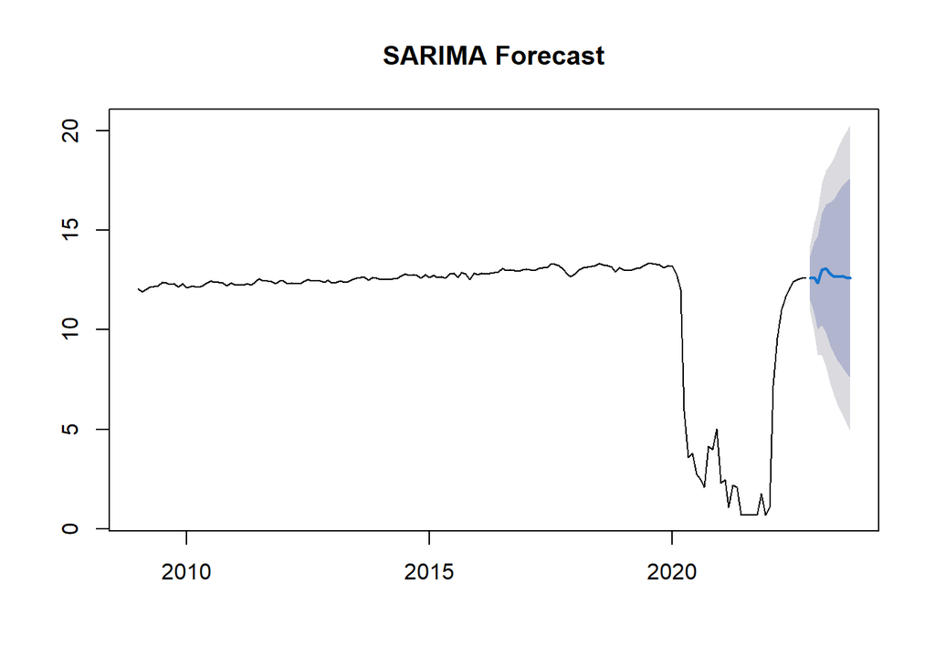

```r
# Arima(1,1,0)(0,1,1)_12
model_terbaik<-Arima(training_ts, order = c(1,1,0), seasonal=list(order=c(0,1,1), periode=12), method = "ML")
ramalan_sarima<- forecast(model_terbaik,11)

plot(ramalan_sarima, main = "SARIMA Forecast")
```

# Akurasi

```r
library(Metrics)
```

```r
a <- exp(ramalan_sarima$mean)
b <- exp(testing_ts)
mape_result <- mape(b,a) * 100
cat("MAPE:", sprintf("%.2f%%", mape_result), "\n")
```

```
## MAPE: 28.81%
```

```r
a <- as.numeric(a)
```

# Plot perbandingan

### Data peramalan intervensi

```r
#Data hasil peramalan intervensi
library(readxl)
testing_data<-data[167:177,2]
ts_testings<-ts(testing_data, frequency = 12)
ts_testings <- ts(ts_testings, frequency = 12)
deta5<-read_excel("C:\\Users\\User\\Documents\\raziq\\semseter 5\\MPDW\\prediksii.xlsx", sheet = 2)
ramalan_intervensi <-ts(deta5, frequency = 12, start = 2022.9)
```

### Data peramalan LSTM

```r
#data peramalan LSTM
datalstm <- read_excel("C:\\Users\\User\\Documents\\raziq\\semseter 5\\MPDW\\prediksiLSTM3.xlsx")
datalstm <- as.numeric(datalstm$prediksi)
datalstmts <- ts(datalstm, frequency = 12, start = 2022.9)
```

### PLot data keseluruhan perbandingan

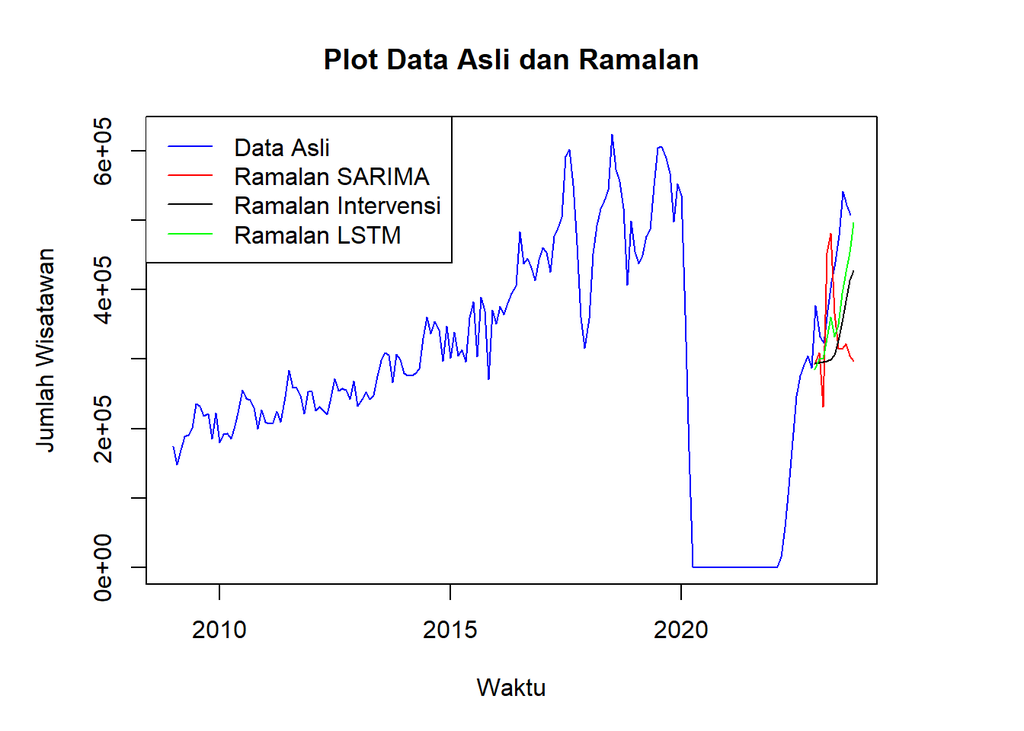

```r
datats <- ts(data[,2], frequency = 12, start = 2009)
ramalan_sarima1 <- ts(a, frequency = 12, start = 2022.9)
# Buat plot data asli
par(mar = c(5, 5, 4, 5))
plot(datats, type = "l", col = "blue", ylim = range(c(datats, ramalan_sarima1, ramalan_intervensi, datalstmts)), ylab = "Jumlah Wisatawan", xlab = "Waktu", main = "Plot Data Asli dan Ramalan")

# Tambahkan plot hasil peramalan sesuai dengan waktu
lines(ramalan_sarima1, col = "red", type = "l")
lines(ramalan_intervensi, col = "black", type = "l")
lines(datalstmts, col = "green", type = "l")

# Tambahkan legenda
legend("topleft", legend = c("Data Asli", "Ramalan SARIMA", "Ramalan Intervensi", "Ramalan LSTM"), col = c("blue", "red","black","green"), lty = 1)
```

### Plot data test dengan peramalan

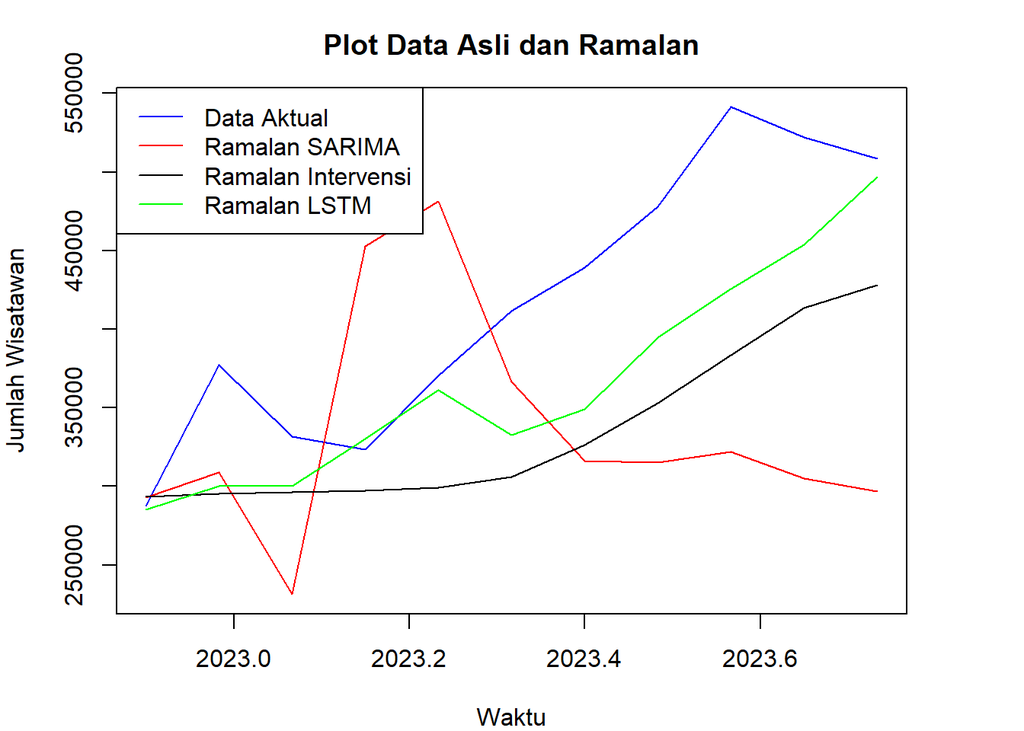

```r
dataaktual <- ts(data[167:177,2],frequency = 12, start = 2022.9)
# Buat plot data asli
par(mar = c(4, 4, 3, 4))
plot(dataaktual, type = "l", col = "blue", ylim = c(min(dataaktual, ramalan_sarima1,ramalan_intervensi, datalstmts), max(dataaktual, ramalan_sarima1,ramalan_intervensi, datalstmts)), ylab = "Jumlah Wisatawan", xlab = "Waktu", main = "Plot Data Asli dan Ramalan")

# Tambahkan plot hasil peramalan sesuai dengan waktu
lines(ramalan_sarima1, col = "red", type = "l")
lines(ramalan_intervensi, col="black", type = "l")
lines(datalstmts, col = "green", type = "l")

# Tambahkan legenda
legend("topleft", legend = c("Data Aktual", "Ramalan SARIMA", "Ramalan Intervensi", "Ramalan LSTM"), col = c("blue", "red","black", "green"), lty = 1)
```

# Plot peramalan 20 periode kedepan

```r
#data peramalan LSTM
datalstm20 <- read_excel("C:\\Users\\User\\Documents\\raziq\\semseter 5\\MPDW\\prediksi20(2).xlsx", sheet = 2)

datalstm20ts <- ts(datalstm20, frequency = 12, start = 2009)

datapredik20 <- ts(datalstm20[178:197,], frequency = 12, start = 2023.7)
```

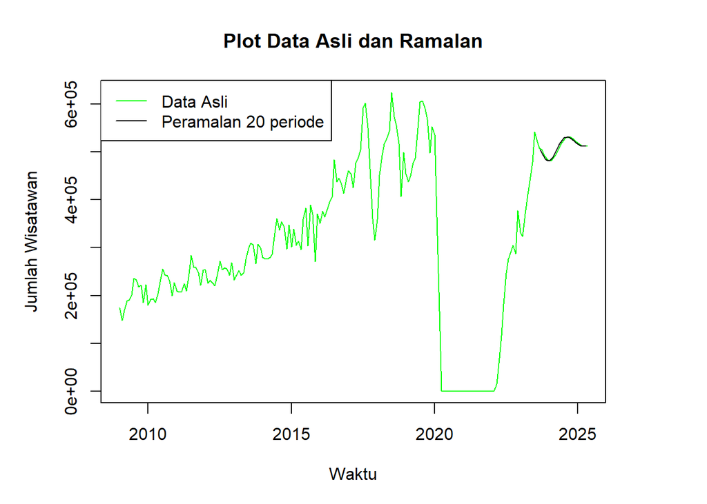

```r
# Buat plot data asli
par(mar = c(5, 5, 4, 5))
plot(datalstm20ts, type = "l", col = "green", ylim = range(c(datalstm20ts)), ylab = "Jumlah Wisatawan", xlab = "Waktu", main = "Plot Data Asli dan Ramalan")


# Tambahkan plot hasil peramalan sesuai dengan waktu
lines(datapredik20, col = "black", type = "l")

# Tambahkan legenda
legend("topleft", legend = c("Data Asli","Peramalan 20 periode"), col = c("green","black"), lty = 1)
```

# Perbandingan MAPE

```r
mape_sarima <- mape(b,a) * 100
mape_intervensi <- mape(b,deta5$prediksi) * 100
mape_LSTM <- mape(b,datalstm) * 100

MAPE_Perbandingan <- data.frame( "Model" =c("SARIMA","Intervensi","LSTM"),"MAPE" = c(mape_sarima,mape_intervensi,mape_LSTM))

dplyr::arrange(.data=MAPE_Perbandingan, MAPE)
```

```
##        Model     MAPE
## 1       LSTM 11.74061
## 2 Intervensi 18.66635
## 3     SARIMA 28.80675
```